# Linear and nonlinear regression

Preclinical and Clinical Data Analysis in Predictive Drug Discovery

2020-12-07

# 1 Background

You have received a dataset (see below) with all the information collected during a drug study of the new antimalarial drug AMP1050.

Malaria is a very serious infectious disease that often leads to death if the victim does not receive the right treatment. Malaria is spread by mosquitoes and the disease occurs mainly in tropical and subtropical parts of the world.<sup>7</sup> Until the middle of the 20th century, however, malaria was also common in Europe, Russia (Soviet Union) and North America. In Sweden, the disease disappeared during the 1930s.<sup>6</sup>

Malaria is caused by parasites belonging to the genus *Plasmodium*. In humans, it is mainly *P. falciparum* and *P. vivax* which causes the disease, but there are also other species that can cause malaria.<sup>6</sup> Virtually all deaths in malaria are caused by *P. falciparum* while *P. vivax* causes fever and great discomfort but rarely leads to death. Every year, around 220 million people worldwide are affected by malaria, and the World Health Organization (WHO) estimates that about 660,000 people died as a result of the disease in 2010.<sup>7</sup>

There is currently no 100% protection against malaria. During trips to malaria-affected areas, prophylactic drugs can be prescribed, but this type of treatment is rarely relevant for those who live and work in these areas. The need for new drugs to cure those affected by *P. falciparum* malaria is also high as the parasites have begun to develop resistance to existing drugs.

The antimalarial drugs available on the market today can be divided into two classes; long-acting drugs, which remain in the body and kill the malaria parasites for several weeks after the patient has taken the drug, and fast-acting drugs, which quickly and effectively kill many malaria parasites but which only remain in the body for a few hours after that that the patient has taken the medicine. To avoid the development of resistance, several antimalarial drugs are often given at the same time, in so-called combination treatments. The most common is that a long-acting antimalarial drug is given together with a fast-acting antimalarial drug.<sup>4</sup> The fast-acting drug is usually an artimisinin derivative, and the fear that *P. falciparum* should develop resistance to artemisinin derivatives is large.<sup>2,7</sup> Development of resistance to artemisinin derivatives has so far been reported from Cambodia and Thailand.<sup>1,3,5</sup>

**References**

1. Dondorp, A. M., F. Nosten, P. Yi, D. Das, A. P. Phyo, J. Tarning, K. M. Lwin, F. Ariey, W. Hanpithakpong, S. J. Lee, P. Ringwald, K. Silamut, M. Imwong, K. Chotivanich, P. Lim, T. Herdman, S. S. An, S. Yeung, P. Singhasivanon, N. P. J. Day, N. Lindegardh, D. Socheat, and N. J. White. Artemisinin resistance in Plasmodium falciparum malaria. *N. Engl. J. Med.*, 2009.doi:10.1056/NEJMoa0808859

2. Duffy, P. E., and C. H. Sibley. Are we losing artemisinin combination therapy already?, 2005.doi:10.1016/S0140-6736(05)67768-9

3. Noedl, H., Y. Se, K. Schaecher, B. L. Smith, D. Socheat, and M. M. Fukuda. Evidence of artemisinin-resistant malaria in Western Cambodia., 2008.doi:10.1056/NEJMc0805011

4. Nosten, F., and P. Brasseur. Combination therapy for malaria: The way forward?, 2002.doi:10.2165/00003495-200262090-00003

5. Phyo, A. P., S. Nkhoma, K. Stepniewska, E. A. Ashley, S. Nair, R. McGready, C. L. Moo, S. Al-Saai, A. M. Dondorp, K. M. Lwin, P. Singhasivanon, N. P. J. Day, N. J. White, T. J. C. Anderson, and F. Nosten. Emergence of artemisinin-resistant malaria on the western border of Thailand: A longitudinal study. *Lancet*, 2012.doi:10.1016/S0140-6736(12)60484-X

6. Smittskyddsinstitutet. Sjukdomsinformation om malaria., 2020.at <https://www.folkhalsomyndigheten.se/smittskydd-beredskap/smittsamma-sjukdomar/malaria/>

7. World Health Organization. WHO: World malaria report. Switzerland: WHO, 2012.

# 2 Study

The pharmaceutical company Academic Malaria-Pharma has, after many years of research, developed a new fast-acting antimalarial drug. The drug, which has been given the working name AMP1050, has shown promising results in preclinical studies (animal studies) and Academic Malaria-Pharma has therefore received the go-ahead to test the drug on patients.

The clinical study was conducted in Uganda and a total of 30 individuals were recruited with *P. falciparum* malaria to the study. Information about all individuals was carefully documented. The study was a so-called *parallel group study* and the individuals were randomized to one of 4 study arms (10 individuals were randomized to study arm-1; 8 individuals were randomized to study arm-2; 5 individuals were randomized to study arm-3 and 7 individuals were randomized to study arm-4). All subjects were given combination therapy with piperakine (a long-acting antimalarial drug) and, either artemisinin or AMP1050. The subjects in study arm-1 received 500 mg artemisinin, the subjects in study arm-2 received 100 mg AMP1050, the subjects in study arm-3 received 250 mg AMP1050 and the subjects in study arm-4 received 500 mg AMP1050. During the study, several blood samples were taken from the individuals. The blood samples were analyzed and the number of parasites in the blood was measured as parasites/µL. Concentration of drugs in the blood samples was also analyzed, and the highest measured drug concentration was recorded for all individuals. The effect of the fast-acting drugs can be calculated as the difference between the number of parasites in the blood before the first dose and the number of parasites in the blood 6 hours after the first dose.

# 3 Dataset

Download, open, and look at the dataset. Each row in the dataset contains information about an individual, each column is a variable. Below is a list of the types of information that can be found in the various columns in the dataset.

Table 3.1: Information that can be found in the various columns in the dataset.

[output not shown]

# 4 Exercises

3. Create scatter plots for the variable pairs below (a scatter plot for each variable pair). Examine the relationship between the variables in the variable pairs by adding regression lines and examine the alignment of the lines. Which variable pairs have linear relationships? Which variable pairs have non-linear relationships?
- Length and Gender
- Gender and Weight
- Weight and length
- Weight and Age
- $C_ {max}$ and Dos
- Dose and lowering of parasite levels in the blood
- $C_ {max}$ and the lowering of parasite levels in the blood
- Body temperature and parasite level in the blood

First we have to load the dataset to R (make sure your “working directory” is where `Dataset.csv` is located):

```r
data <- read.csv("Dataset.csv")
```

For length and sex (first variable pairs) we can create a scatter plot with the following code. The result shows data, regression line and uncertainty around the line (95% confidence interval).

```r
# install the ggplot2 library
if(!nzchar(system.file(package = "ggplot2"))) install.packages("ggplot2")

# load the ggplot2 library
library(ggplot2)

# make the plot
p1 <- ggplot(data=data, aes(x=female,y=height)) +
  geom_point() +
  geom_smooth(method="lm")

# show the plot
p1
```

Then we can also get a more detailed analysis of the linear regression with the following code:

```r
# evaluate the linear fit to data
fit_1 <- lm(height~female,data)

# summarize that fit to data
summary(fit_1)
```

**Tip 1:** When you are going to make scatter diagrams with Dos and/or Cmax, you should use data for individuals who received AMP1050.

**Tip 2:** *The decrease in parasite levels* is the difference in the number of parasites/µL blood at the beginning of the study compared to 6 hours after the first drug dose (Parasite 0h - Parasite 6h) and *Decrease in temperature* is the difference in body temperature at the beginning of the study compared to 6 hours after the first drug dose (Temp 0h - Temp 6h). What do the negative values in these calculations mean?

**Tip 3:** When you plot “Body temperature and parasite level in the blood”, then use that you have data for these at both 0 hours and 6 hours. First make a scatter plot for the variables at 0 hours and then another scatter plot for the variables at 6 hours.

**Part 1**

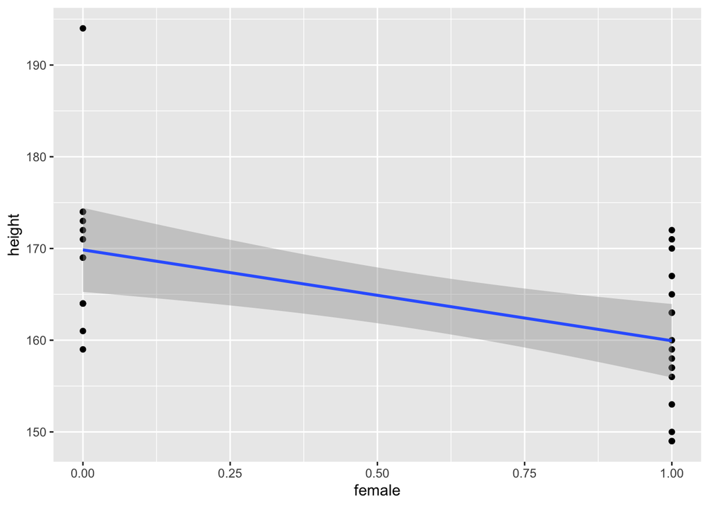

```r
# read in the data
# (make sure that your working directory is where the dataset is located)
data <- read.csv("Dataset.csv")

# load the ggplot2 library
library(ggplot2)

# make the plot
p1 <- ggplot(data=data, aes(x=female,y=height)) +
  geom_point() +
  geom_smooth(method="lm")

# show the plot
p1
```

```r
# evaluate the linear fit to data
fit_1 <- lm(height~female,data)

# summarize that fit to data
summary(fit_1)
```

```
##
## Call:
## lm(formula = height ~ female, data = data)
##
## Residuals:
##      Min       1Q   Median       3Q      Max
## -10.9412  -5.8462  -0.8462   3.9038  24.1538
##
## Coefficients:
##             Estimate Std. Error t value Pr(>|t|)
## (Intercept)  169.846      2.236  75.944  < 2e-16 ***
## female        -9.905      2.971  -3.334  0.00242 **
## ---
## Signif. codes:  0 '***' 0.001 '**' 0.01 '*' 0.05 '.' 0.1 ' ' 1
##
## Residual standard error: 8.064 on 28 degrees of freedom
## Multiple R-squared:  0.2842, Adjusted R-squared:  0.2586
## F-statistic: 11.12 on 1 and 28 DF,  p-value: 0.002421
```

Scatter diagram showing how the height covaries with sex. The regression equation shows that the average Ugandan man is 9.91 cm taller than the average Ugandan woman (the regression coefficient “Intercept”, b, is -9.91).

The coefficient of determination (“Multiple R-squatred”) shows that 28.4% of the variation in length between different individuals can be explained by the gender of the individuals (i.e. 71.6% of the variation in length is due to other things than that the individuals have different genders). The correlation coefficient (r) can be calculated by $r=\sqrt {r ^ 2} =\pm 0.533$. Since the regression coefficient is negative, the correlation coefficient is also negative. A correlation coefficient of -0.533 means that there is a relatively weak, negative (linear) relationship between the variables length and gender (male = 0, female = 1).

**Part 2**

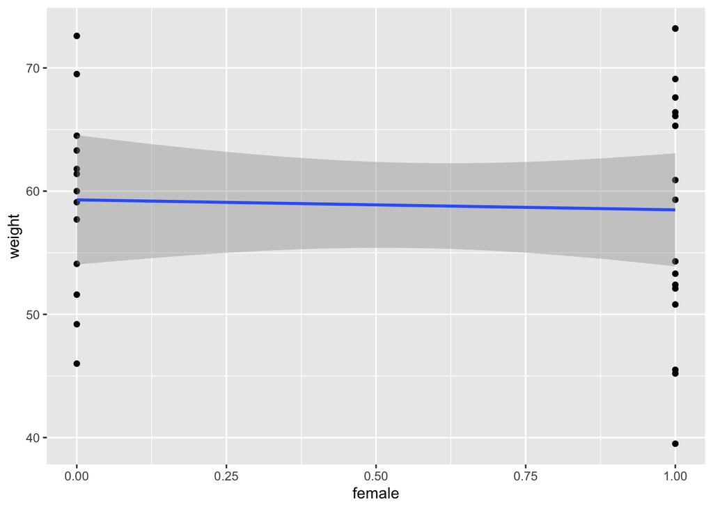

```r
# make the plot
p2 <- ggplot(data=data, aes(x=female,y=weight)) +
  geom_point() +
  geom_smooth(method="lm")

# show the plot
p2
```

```r
# evaluate the linear fit to data
fit_2 <- lm(weight~female,data)

# summarize that fit to data
summary(fit_2)
```

```
##
## Call:
## lm(formula = weight ~ female, data = data)
##
## Residuals:
##      Min       1Q   Median       3Q      Max
## -18.9824  -6.3074   0.7627   7.4176  14.7176
##
## Coefficients:
##             Estimate Std. Error t value Pr(>|t|)
## (Intercept)   59.292      2.564  23.129   <2e-16 ***
## female        -0.810      3.405  -0.238    0.814
## ---
## Signif. codes:  0 '***' 0.001 '**' 0.01 '*' 0.05 '.' 0.1 ' ' 1
##
## Residual standard error: 9.243 on 28 degrees of freedom
## Multiple R-squared:  0.002016,   Adjusted R-squared:  -0.03363
## F-statistic: 0.05657 on 1 and 28 DF,  p-value: 0.8137
```

Diagram showing how weight covaries with gender. The regression equation shows that the average Ugandan man weighs 0.81 kg more than the average Ugandan woman (the regression coefficient “Intercept”, b, is -0.81).

The determination coefficient ($r^2$) shows that 0.2% of the variation in weight between different individuals can be explained by the gender of the individuals (i.e. 99.8% of the variation in weight is due to other things than that the individuals have different genders). The correlation coefficient (s) can be calculated to $\pm0.045$. Since the regression coefficient is negative, the correlation coefficient is also negative. A correlation coefficient of -0.045 means that there is no linear relationship between the variables weight and gender (the relationship we see has probably arisen by chance and would not be significant in a hypothesis test).

**Part 3**

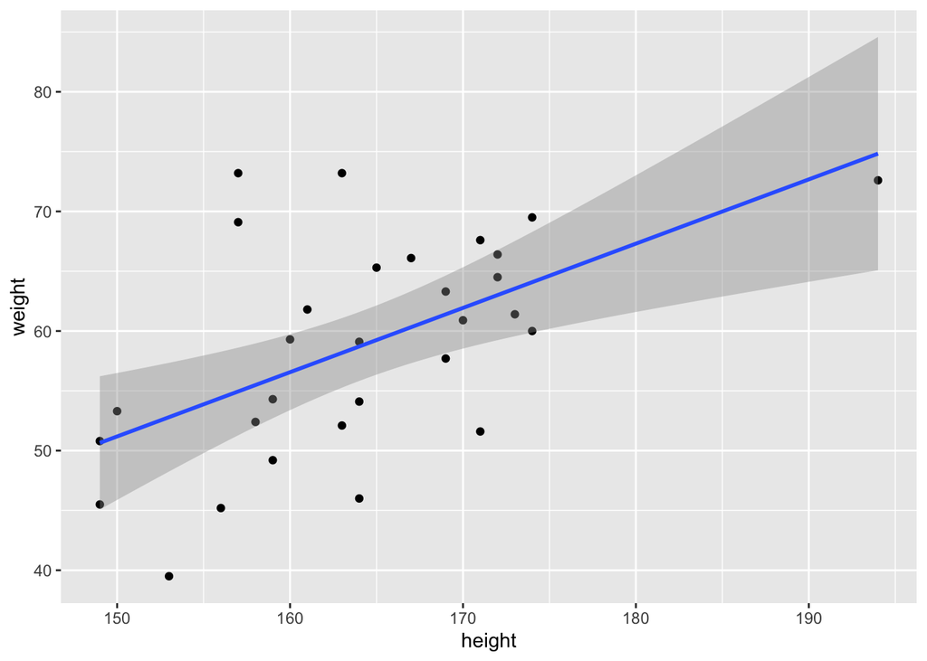

```r
# make the plot
p3 <- ggplot(data=data, aes(x=height,y=weight)) +
  geom_point() +
  geom_smooth(method="lm")

# show the plot
p3
```

```r
# evaluate the linear fit to data
fit_3 <- lm(weight~height,data)

# summarize that fit to data
summary(fit_3)
```

```
##
## Call:
## lm(formula = weight ~ height, data = data)
##
## Residuals:
##      Min       1Q   Median       3Q      Max
## -13.2972  -4.4763  -0.4399   4.3764  18.2535
##
## Coefficients:
##             Estimate Std. Error t value Pr(>|t|)
## (Intercept) -29.4167    25.1335  -1.170  0.25170
## height        0.5373     0.1528   3.517  0.00151 **
## ---
## Signif. codes:  0 '***' 0.001 '**' 0.01 '*' 0.05 '.' 0.1 ' ' 1
##
## Residual standard error: 7.706 on 28 degrees of freedom
## Multiple R-squared:  0.3064, Adjusted R-squared:  0.2816
## F-statistic: 12.37 on 1 and 28 DF,  p-value: 0.001509
```

Diagram showing how the weight covaries with the height. The regression equation shows that for an individual in Uganda, the weight increases by an average of 0.54 kg as the height increases by 1.00 cm (the regression coefficient, b, is 0.54).

Note that the slope of the regression line is greatly affected by a so-called outlier.

**Part 4**

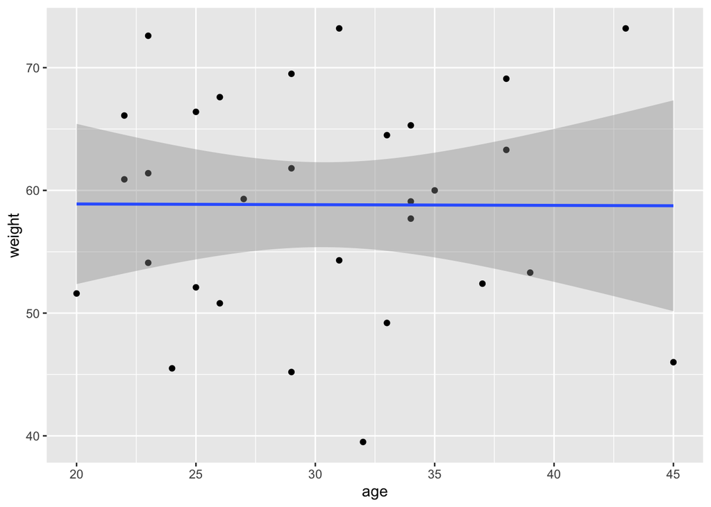

```r
# make the plot
p4 <- ggplot(data=data, aes(x=age,y=weight)) +
  geom_point() +
  geom_smooth(method="lm")

# show the plot
p4
```

```r
# evaluate the linear fit to data
fit_4 <- lm(weight~age,data)

# summarize that fit to data
summary(fit_4)
```

```
##
## Call:
## lm(formula = weight ~ age, data = data)
##
## Residuals:
##      Min       1Q   Median       3Q      Max
## -19.3237  -6.6718   0.8205   7.0358  14.4399
##
## Coefficients:
##              Estimate Std. Error t value Pr(>|t|)
## (Intercept) 59.008769   8.113716   7.273 6.44e-08 ***
## age         -0.005784   0.261624  -0.022    0.983
## ---
## Signif. codes:  0 '***' 0.001 '**' 0.01 '*' 0.05 '.' 0.1 ' ' 1
##
## Residual standard error: 9.252 on 28 degrees of freedom
## Multiple R-squared:  1.745e-05,  Adjusted R-squared:  -0.0357
## F-statistic: 0.0004887 on 1 and 28 DF,  p-value: 0.9825
```

Spread diagram showing how weight covaries with age. The regression equation shows that for an individual in Uganda, the weight decreases by an average of 0.0058 kg as the age increases by 1.00 years (the regression coefficient, b, is -0.0058).

**Part 5**

Data for individuals receiving AMP1050:

```r
data_amp <- subset(data, drug==2)
```

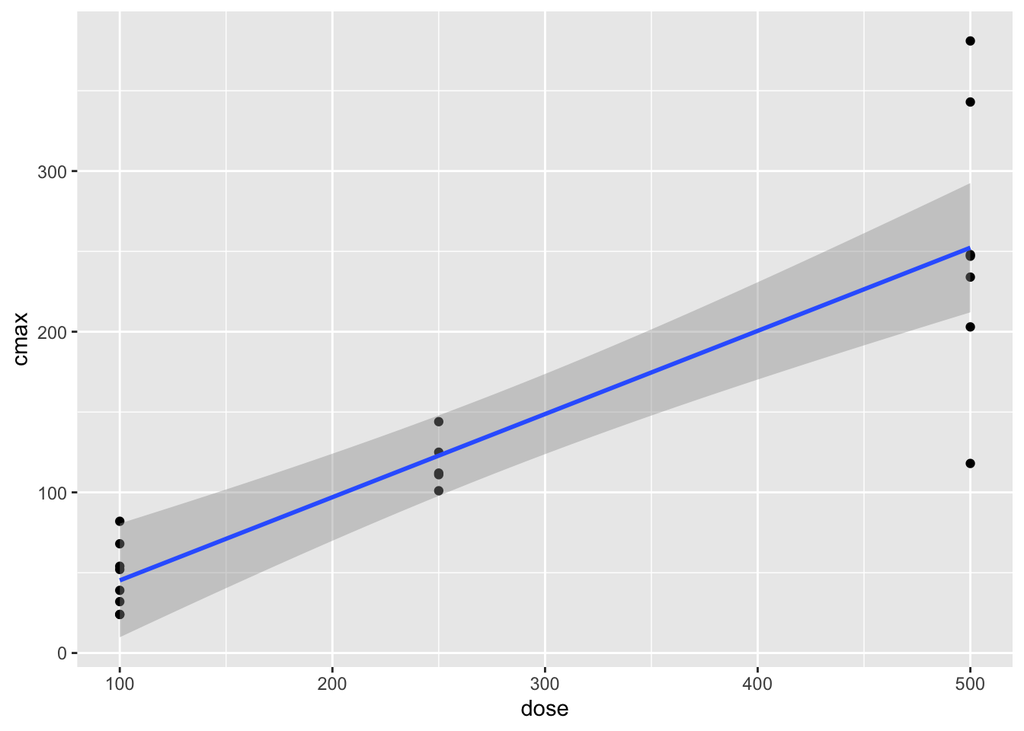

```r
# make the plot
p5 <- ggplot(data=data_amp, aes(x=dose,y=cmax)) +
  geom_point() +
  geom_smooth(method="lm")

# show the plot
p5
```

```r
# evaluate the linear fit to data
fit_5 <- lm(cmax~dose,data_amp)

# summarize that fit to data
summary(fit_5)
```

```
##
## Call:
## lm(formula = cmax ~ dose, data = data_amp)
##
## Residuals:
##      Min       1Q   Median       3Q      Max
## -134.287  -19.017   -5.748   11.877  128.713
##
## Coefficients:
##             Estimate Std. Error t value Pr(>|t|)
## (Intercept) -6.55966   22.21174  -0.295    0.771
## dose         0.51769    0.06786   7.628 4.79e-07 ***
## ---
## Signif. codes:  0 '***' 0.001 '**' 0.01 '*' 0.05 '.' 0.1 ' ' 1
##
## Residual standard error: 52.67 on 18 degrees of freedom
## Multiple R-squared:  0.7638, Adjusted R-squared:  0.7506
## F-statistic: 58.19 on 1 and 18 DF,  p-value: 4.792e-07
```

Dispersion diagram showing how the maximum drug concentration (Cmax) covaries with the drug dose. Data, with the drug AMP1050 alone, were used. The regression equation shows that for an average individual in Uganda, the maximum drug concentration increases by 0.518 ng/mL as the dose increases by 1.00 mg (the regression coefficient (slope), b, is 0.518).

The coefficient of determination ($r^2$) shows that 76.4% of the variation in Cmax between different individuals can be explained by the individuals receiving different drug doses (i.e. 23.6% of the variation in Cmax is due to other things than that the individuals received different drug doses). The correlation coefficient (r) can be calculated to $r = \pm 0.874$. Since the regression coefficient is positive, the correlation coefficient is also positive. A correlation coefficient of 0.874 means that there is a strong, positive, linear relationship between the variables Cmax and dose of drug.

**Part 6**

We calculate the parasite difference

```r
data$par_delta <- data$parasite_0h - data$parasite_6h
```

And then the difference for individuals who received AMP1050:

```r
data_amp <- subset(data, drug==2)
```

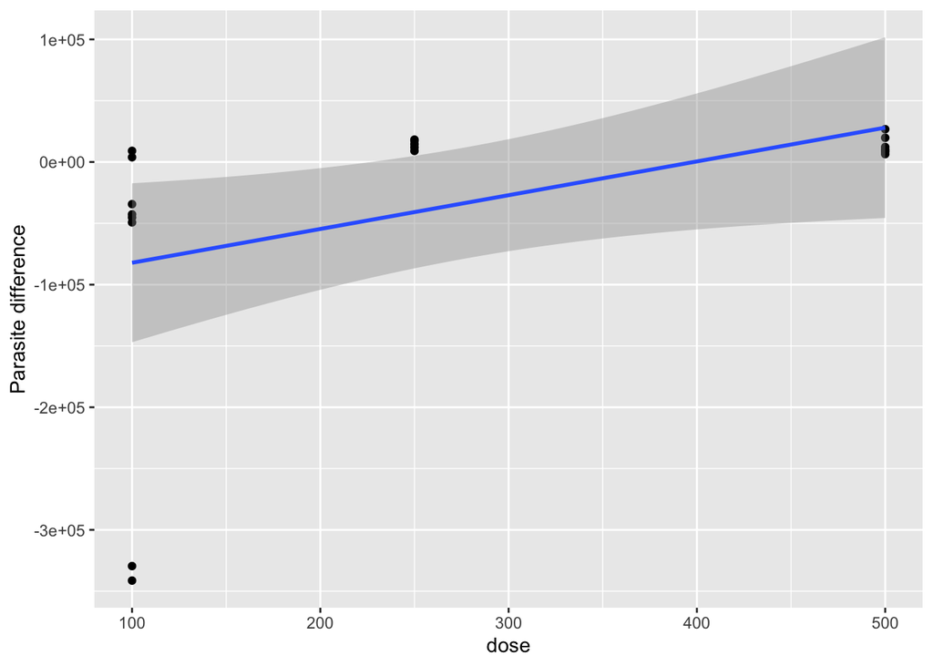

```r
# make the plot
p6 <- ggplot(data=data_amp, aes(x=dose,y=par_delta)) +
  geom_point() +
  geom_smooth(method="lm")

# show the plot
p6  + ylab("Parasite difference")
```

```r
# evaluate the linear fit to data
fit_6 <- lm(par_delta~dose,data_amp)

# summarize that fit to data
summary(fit_6)
```

```
##
## Call:
## lm(formula = par_delta ~ dose, data = data_amp)
##
## Residuals:
##     Min      1Q  Median      3Q     Max
## -259196  -18025   34916   53457   91260
##
## Coefficients:
##              Estimate Std. Error t value Pr(>|t|)
## (Intercept) -109713.4    40677.4  -2.697   0.0147 *
## dose            275.5      124.3   2.217   0.0398 *
## ---
## Signif. codes:  0 '***' 0.001 '**' 0.01 '*' 0.05 '.' 0.1 ' ' 1
##
## Residual standard error: 96460 on 18 degrees of freedom
## Multiple R-squared:  0.2144, Adjusted R-squared:  0.1708
## F-statistic: 4.913 on 1 and 18 DF,  p-value: 0.03977
```

Dispersion diagram showing how the decrease in the number of parasites in the blood covaries with the drug dose. The dataset with only the drug AMP1050 was used. The scatter plot shows that there seems to be a covariation between the variables but that this covariation is not linear (the linear regression line does not go through the points at all).

**Part 7**

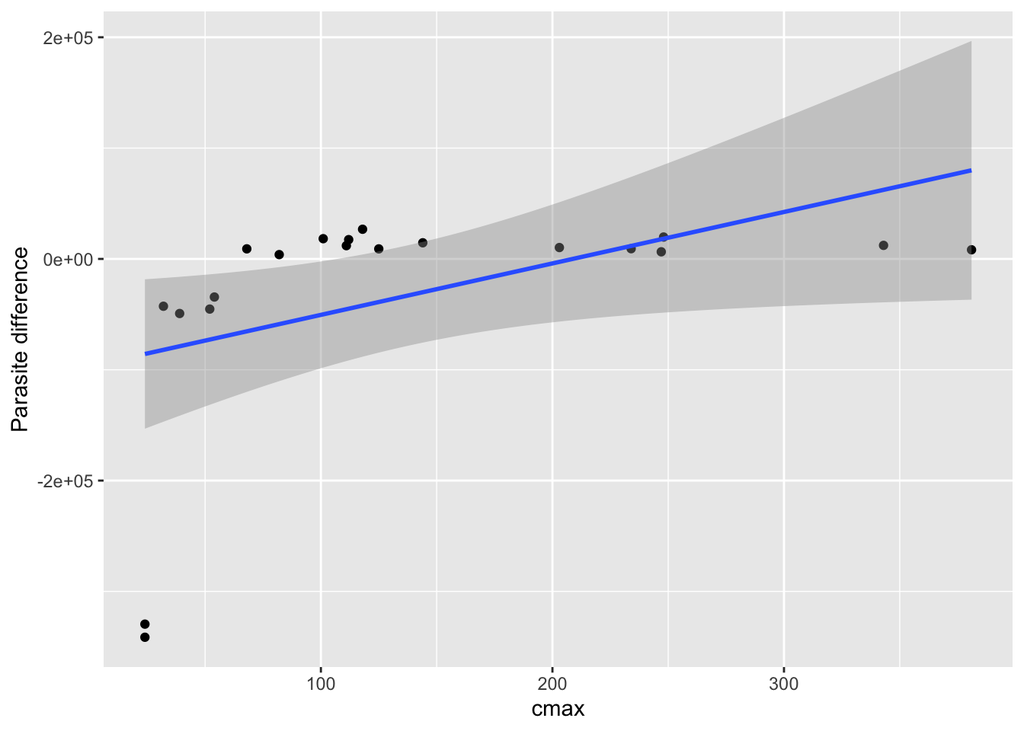

```r
# make the plot
p7 <- ggplot(data=data_amp, aes(x=cmax,y=par_delta)) +
  geom_point() +
  geom_smooth(method="lm")

# show the plot
p7  + ylab("Parasite difference")
```

```r
# evaluate the linear fit to data
fit_7 <- lm(par_delta~cmax,data_amp)

# summarize that fit to data
summary(fit_7)
```

```
##
## Call:
## lm(formula = par_delta ~ cmax, data = data_amp)
##
## Residuals:
##     Min      1Q  Median      3Q     Max
## -255590   -4707   33510   58593   74440
##
## Coefficients:
##             Estimate Std. Error t value Pr(>|t|)
## (Intercept) -96912.7    35969.9  -2.694   0.0148 *
## cmax           464.2      209.9   2.212   0.0402 *
## ---
## Signif. codes:  0 '***' 0.001 '**' 0.01 '*' 0.05 '.' 0.1 ' ' 1
##
## Residual standard error: 96510 on 18 degrees of freedom
## Multiple R-squared:  0.2137, Adjusted R-squared:   0.17
## F-statistic: 4.891 on 1 and 18 DF,  p-value: 0.04017
```

Dispersion diagram showing how the decrease in the number of parasites in the blood covaries with the maximum drug concentration. The dataset with only the drug AMP1050 was used. The scatter plot shows that there is a clear covariation between the variables but that this covariation is not linear (the linear regression line does not go through the points at all).

**Part 8**

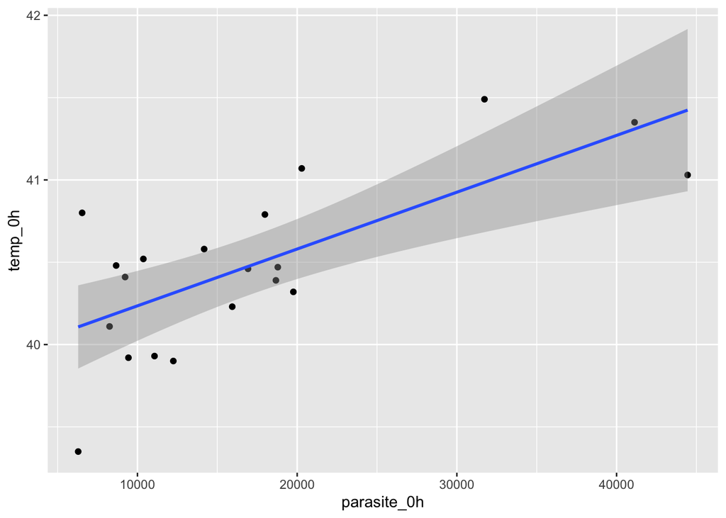

```r
# make the plot
p8 <- ggplot(data=data_amp, aes(x=parasite_0h,y=temp_0h)) +
  geom_point() +
  geom_smooth(method="lm")

p8
```

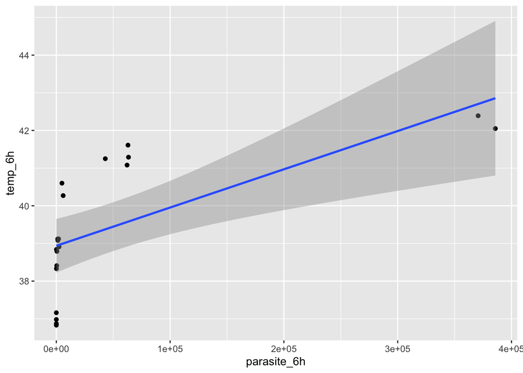

```r
p9 <- ggplot(data=data_amp, aes(x=parasite_6h,y=temp_6h)) +
  geom_point() +
  geom_smooth(method="lm")

p9
```

```r
# evaluate the linear fit to data
fit_8 <- lm(temp_0h~parasite_0h,data_amp)
fit_9 <- lm(temp_6h~parasite_6h,data_amp)

# summarize that fit to data
summary(fit_8)
```

```
##
## Call:
## lm(formula = temp_0h ~ parasite_0h, data = data_amp)
##
## Residuals:
##      Min       1Q   Median       3Q      Max
## -0.75707 -0.26293 -0.03943  0.27394  0.68441
##
## Coefficients:
##              Estimate Std. Error t value Pr(>|t|)
## (Intercept) 3.989e+01  1.604e-01 248.656  < 2e-16 ***
## parasite_0h 3.451e-05  8.010e-06   4.308 0.000423 ***
## ---
## Signif. codes:  0 '***' 0.001 '**' 0.01 '*' 0.05 '.' 0.1 ' ' 1
##
## Residual standard error: 0.3737 on 18 degrees of freedom
## Multiple R-squared:  0.5077, Adjusted R-squared:  0.4803
## F-statistic: 18.56 on 1 and 18 DF,  p-value: 0.0004233
```

```r
summary(fit_9)
```

```
##
## Call:
## lm(formula = temp_6h ~ parasite_6h, data = data_amp)
##
## Residuals:
##      Min       1Q   Median       3Q      Max
## -2.10758 -0.65794 -0.07518  1.33136  2.03281
##
## Coefficients:
##              Estimate Std. Error t value Pr(>|t|)
## (Intercept) 3.894e+01  3.385e-01 115.016  < 2e-16 ***
## parasite_6h 1.016e-05  2.764e-06   3.675  0.00173 **
## ---
## Signif. codes:  0 '***' 0.001 '**' 0.01 '*' 0.05 '.' 0.1 ' ' 1
##
## Residual standard error: 1.38 on 18 degrees of freedom
## Multiple R-squared:  0.4286, Adjusted R-squared:  0.3969
## F-statistic:  13.5 on 1 and 18 DF,  p-value: 0.001733
```

Dispersion diagram showing how body temperature covaries with the number of parasites in the blood. The dataset with only the drug AMP1050 was used. The scatter plot shows that there is a clear covariation between the variables but that this covariation is not linear.

4. Regression analyses, i.e. hypothesis tests where it is examined whether there is any significant linear relationship between two (or more) variables, can easily be performed with built-in functions in R.

$H_0$: $b = 0$, there is no relationship between the variables, any observed relationship has arisen by chance.

$H_1$: $b \ne 0$, there is a relationship between the variables, any observed relationship has not arisen by chance (two-sided test).

You have all the information needed from the results of the `lm ()` and `summary ()` exercises. The results produced (automatically) in regression analyzes are extensive. A review of the most important parameters follows below.

You know the value of the $R^2$ value (determination coefficient).

F-statistics indicate the p-value for the probability that the relationship observed between the variables has arisen by chance. If the p-value is below the selected significance level (0.05 if the significance level is 5%) then $H_0$ is rejected. Which of the relationships in the regression analyzes are significant at the 5% significance level? Which relationships are significant at the 1% significance level?

You will also find calculated t-values and the corresponding p-values (Pr (> | t |)) for each regression parameter. Are all the p-values for the regression coefficient below the selected significance level?

*Solution*. The relationship between height and weight is significant at both 1% and 5% significance level (p-value: 0.0015). The relationship between age and weight is not significant at all (p-value: 0.98). The relationship between Cmax and the decrease in the number of parasites in the blood is significant at the 5% significance level but not at the 1% significance level (p-value: 0.040).

5. A linear regression analysis can also analyze the relationship between more than two variables. In these cases, one examines how several different independent variables affect a dependent variable. Examine the relationship between height (independent variable 1), age (independent variable 2) and weight (dependent variable). Also examine how correlation terms effect the results.

```r
fit_10 <- lm(weight~height+age,data)
summary(fit_10)
```

```
##
## Call:
## lm(formula = weight ~ height + age, data = data)
##
## Residuals:
##      Min       1Q   Median       3Q      Max
## -15.7545  -4.5390  -0.1182   4.8809  18.3903
##
## Coefficients:
##             Estimate Std. Error t value Pr(>|t|)
## (Intercept) -41.9958    28.6691  -1.465  0.15451
## height        0.5755     0.1587   3.626  0.00118 **
## age           0.2083     0.2263   0.920  0.36548
## ---
## Signif. codes:  0 '***' 0.001 '**' 0.01 '*' 0.05 '.' 0.1 ' ' 1
##
## Residual standard error: 7.727 on 27 degrees of freedom
## Multiple R-squared:  0.3275, Adjusted R-squared:  0.2777
## F-statistic: 6.574 on 2 and 27 DF,  p-value: 0.004721
```

```r
fit_11 <- lm(weight~height*age,data)
summary(fit_11)
```

```
##
## Call:
## lm(formula = weight ~ height * age, data = data)
##
## Residuals:
##      Min       1Q   Median       3Q      Max
## -15.6486  -4.5111  -0.3149   4.9366  18.3009
##
## Coefficients:
##               Estimate Std. Error t value Pr(>|t|)
## (Intercept) -79.301734 135.377696  -0.586    0.563
## height        0.801977   0.818768   0.979    0.336
## age           1.567521   4.821951   0.325    0.748
## height:age   -0.008281   0.029344  -0.282    0.780
##
## Residual standard error: 7.862 on 26 degrees of freedom
## Multiple R-squared:  0.3295, Adjusted R-squared:  0.2522
## F-statistic:  4.26 on 3 and 26 DF,  p-value: 0.0142
```

- Examine the p-values for the regression coefficients. Are any of the variables that have a significant relationship with weight (at the 5% significance level) when both variables are used to predict weight?

*Solution*. x-variable 1 (height) has a significant relationship with weight at both 1% and 5% significance level (p-value: 0.0012) but x-variable 2 (age) has no significant relationship with weight (p-value: 0.37). Note, however, that the p-value for the relationship between age and weight is significantly lower in the multiple regression analysis, as the relationship between height and weight is also included. This can also be seen in the value of the coefficient of determination which was 0.306 when only the height was used to predict the weight, 0.0000175 when only the age was used to predict the weight and 0.327 when both the height and the age were used to predict the weight. This means that height and age together explain more of the differences observed in weight than height does on its own, but the difference is not significant.

When a correlation term is added to the model then all model parameter are not different from zero according to the p-values. This can be interpreted as the addition of this extra correlation term makes the model over-parameterized, so no parameters can be estimated with enough precision.

6. The decrease in parasite levels in the blood correlates with the maximum drug concentration for AMP1050, which we saw in above. The scatter plot shows that there is a clear covariation between the variables but that this covariation is not linear (the linear regression line does not go through the points at all). We will try to describe that covariation with a non-linear model.

First, we will try to get the parasite difference on a skale that varies less. Often you can do this with a log transformation of data.

```r
data$log_par_delta <- log(data$parasite_0h) - log(data$parasite_6h)
data_AMP1050 <- subset(data, drug==2)
```

Then we can visualize this

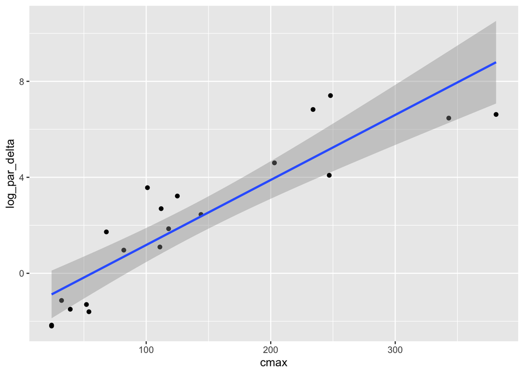

```r
plot1 <- ggplot(data=data_AMP1050,aes(x=cmax,y=log_par_delta)) +  geom_point()
plot1 + geom_smooth(method="lm")
```

```r
lm_fit <- lm(log_par_delta~cmax,data_AMP1050)
summary(lm_fit)
```

```
##
## Call:
## lm(formula = log_par_delta ~ cmax, data = data_AMP1050)
##
## Residuals:
##     Min      1Q  Median      3Q     Max
## -2.1756 -1.2040 -0.1512  1.2335  2.3622
##
## Coefficients:
##              Estimate Std. Error t value Pr(>|t|)
## (Intercept) -1.532025   0.530433  -2.888  0.00979 **
## cmax         0.027108   0.003095   8.758  6.6e-08 ***
## ---
## Signif. codes:  0 '***' 0.001 '**' 0.01 '*' 0.05 '.' 0.1 ' ' 1
##
## Residual standard error: 1.423 on 18 degrees of freedom
## Multiple R-squared:  0.8099, Adjusted R-squared:  0.7994
## F-statistic: 76.69 on 1 and 18 DF,  p-value: 6.601e-08
```

It looks more linear with this transformation of data, but let’s try a non-linear fit with an $E_{max}$ model:

```r
nls_fit <- nls(log_par_delta ~ E0 + (EMAX*cmax)/(EC50 + cmax),  data=data_AMP1050,
               start = list(E0 = -1, EMAX = 11,
                            EC50 = 100), trace = TRUE)
```

```
## 145.6668 :   -1  11 100
## 19.37285 :   -4.20065  15.92687 168.79580
## 18.50535 :   -4.58014  16.43908 152.18639
## 18.48428 :   -4.559657  16.501324 155.574185
## 18.48425 :   -4.565618  16.495989 155.238106
## 18.48425 :   -4.565074  16.496694 155.275759
## 18.48425 :   -4.565135  16.496617 155.271585
```

```r
summary(nls_fit)
```

```
##
## Formula: log_par_delta ~ E0 + (EMAX * cmax)/(EC50 + cmax)
##
## Parameters:
##      Estimate Std. Error t value Pr(>|t|)
## E0     -4.565      1.240  -3.682  0.00185 **
## EMAX   16.497      1.897   8.695 1.15e-07 ***
## EC50  155.272     74.303   2.090  0.05199 .
## ---
## Signif. codes:  0 '***' 0.001 '**' 0.01 '*' 0.05 '.' 0.1 ' ' 1
##
## Residual standard error: 1.043 on 17 degrees of freedom
##
## Number of iterations to convergence: 6
## Achieved convergence tolerance: 1.538e-06
```

And then an $E_{max}$ mode with a hill coefficient:

```r
nls_fit_2 <- nls(log_par_delta ~ E0 + (EMAX*cmax^HILL)/(EC50^HILL + cmax^HILL),  data=data_AMP1050,
               start = list( E0= -1,EMAX = 11,
                            EC50 = 100,HILL=2), trace = TRUE)
```

```
## 138.9503 :   -1  11 100   2
## 18.23874 :   -2.960249  11.095440 113.610529   1.583155
## 17.86232 :   -2.804838  11.136377 122.182870   1.661635
## 17.8606 :   -2.835417  11.180481 121.891731   1.657460
## 17.8606 :   -2.834639  11.177753 121.873660   1.658090
## 17.8606 :   -2.834854  11.178398 121.877055   1.657945
```

```r
summary(nls_fit_2)
```

```
##
## Formula: log_par_delta ~ E0 + (EMAX * cmax^HILL)/(EC50^HILL + cmax^HILL)
##
## Parameters:
##      Estimate Std. Error t value Pr(>|t|)
## E0    -2.8349     1.5832  -1.791  0.09229 .
## EMAX  11.1784     4.1293   2.707  0.01554 *
## EC50 121.8771    32.3499   3.767  0.00168 **
## HILL   1.6579     0.9165   1.809  0.08928 .
## ---
## Signif. codes:  0 '***' 0.001 '**' 0.01 '*' 0.05 '.' 0.1 ' ' 1
##
## Residual standard error: 1.057 on 16 degrees of freedom
##
## Number of iterations to convergence: 5
## Achieved convergence tolerance: 9.044e-06
```

We can visualize how all models fit the data together:

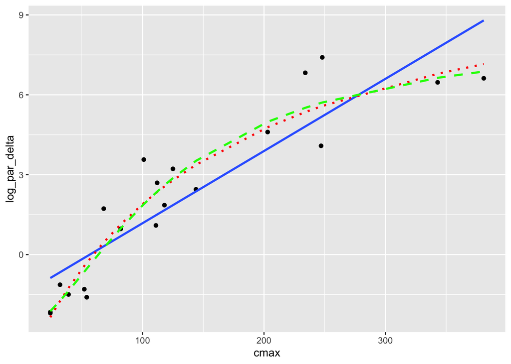

```r
plot1 + geom_smooth(method="lm",se = FALSE) +
  geom_line(aes(y=fitted(nls_fit)),col="red",lty="dotted",lwd=1) +
  geom_line(aes(y=fitted(nls_fit_2)),col="green",lty="dashed",lwd=1)
```

And we can decide which one adapts best based on AIC values:

```r
AIC(lm_fit,nls_fit,nls_fit_2)
```

```
##           df      AIC
## lm_fit     3 74.76444
## nls_fit    4 63.18127
## nls_fit_2  5 64.49484
```

The best model has the lowest AIC.

Visualization of this model with uncertainty. First, we calculate confidence intervals on each x-value:

```r
fit_to_plot <- ??? # Give a model fit that you want to use


get_pred_ci <- function(fit_to_plot){
  if(class(fit_to_plot)=="nls"){
    if(!nzchar(system.file(package = "mvtnorm"))) install.packages("mvtnorm")
    for(i in 1:500){
      if(i==1) nls_pred <- c()
      params <- drop(mvtnorm::rmvnorm(1,coef(fit_to_plot),
                                      sigma=vcov(fit_to_plot)))
      nls_pred <- cbind(nls_pred,predict(fit_to_plot,params))
    }
    nls_pred <- t(apply(nls_pred,1,quantile,probs = c(0.025, 0.975)))
    nls_pred <- as.data.frame(cbind(fit=predict(fit_to_plot),nls_pred))
    mod_pred <- nls_pred
    names(mod_pred) <- c("fit","lwr","upr")
  } else if(class(fit_to_plot)=="lm"){
    mod_pred <- data.frame(predict(lm_fit, interval = "confidence"))
  }
  return(mod_pred)
}

mod_pred_ci <- get_pred_ci(fit_to_plot)
```

Then we plot

```r
plot1 +
  geom_ribbon(aes(ymin=mod_pred_ci$lwr, ymax=mod_pred_ci$upr), fill="lightblue",alpha=0.5) +
  geom_line(aes(y=mod_pred_ci$fit),col="blue",lwd=1)
```

- Which model fits best? Does the model provide any information about the drug?

*Solution*. The best model has the lowest AIC. In this case the $E_{max}$ model is best. Visualization with uncertainty:

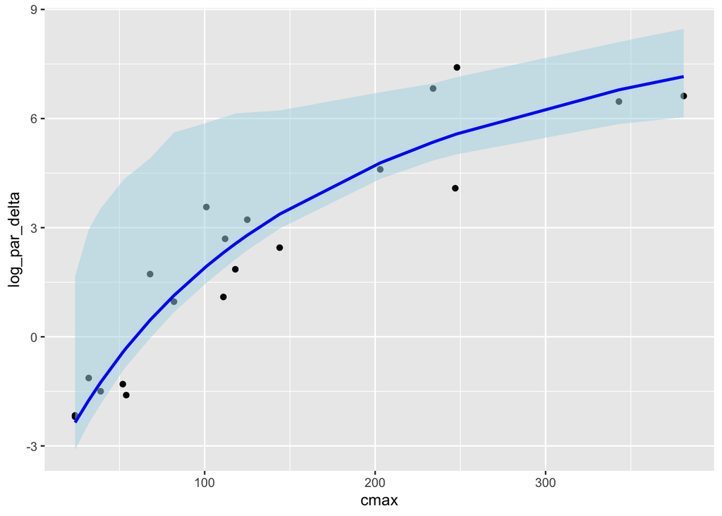

```r
fit_to_plot <- nls_fit # Give a model fit that you want to use


get_pred_ci <- function(fit_to_plot){
  if(class(fit_to_plot)=="nls"){
    if(!nzchar(system.file(package = "mvtnorm"))) install.packages("mvtnorm")
    for(i in 1:500){
      if(i==1) nls_pred <- c()
      params <- drop(mvtnorm::rmvnorm(1,coef(fit_to_plot),
                                      sigma=vcov(fit_to_plot)))
      nls_pred <- cbind(nls_pred,predict(fit_to_plot,params))
    }
    nls_pred <- t(apply(nls_pred,1,quantile,probs = c(0.025, 0.975)))
    nls_pred <- as.data.frame(cbind(fit=predict(fit_to_plot),nls_pred))
    mod_pred <- nls_pred
    names(mod_pred) <- c("fit","lwr","upr")
  } else if(class(fit_to_plot)=="lm"){
    mod_pred <- data.frame(predict(lm_fit, interval = "confidence"))
  }
  return(mod_pred)
}

mod_pred_ci <- get_pred_ci(fit_to_plot)

plot1 +
  geom_ribbon(aes(ymin=mod_pred_ci$lwr, ymax=mod_pred_ci$upr), fill="lightblue",alpha=0.5) +
  geom_line(aes(y=mod_pred_ci$fit),col="blue",lwd=1)
```

```r
summary(nls_fit)
```

```
##
## Formula: log_par_delta ~ E0 + (EMAX * cmax)/(EC50 + cmax)
##
## Parameters:
##      Estimate Std. Error t value Pr(>|t|)
## E0     -4.565      1.240  -3.682  0.00185 **
## EMAX   16.497      1.897   8.695 1.15e-07 ***
## EC50  155.272     74.303   2.090  0.05199 .
## ---
## Signif. codes:  0 '***' 0.001 '**' 0.01 '*' 0.05 '.' 0.1 ' ' 1
##
## Residual standard error: 1.043 on 17 degrees of freedom
##
## Number of iterations to convergence: 6
## Achieved convergence tolerance: 1.538e-06
```

The model says that the maximum effect of the drug will be a 16.5 log virus reduction from 0 to 6 hours. Half of that effect is reached when $C_{max}$ reaches 155.